# DSC - SwiftKey Capstone

Moreno Riccardi

Tuesday, December 22, 2015

# Introduction

Our purpose is to build a predictive text model, that can help people who are spending an increasing amount of time on their mobile devices for email, social networking, banking and a whole range of other activities. But typing on mobile devices can be a serious pain. So, as SwiftKey does on their smart keyboard, I’ll build a Shiny application that implement predictive text models. When someone types:

I went to the

the application will present three options for what the next word might be. For example, the three words might be gym, store, restaurant.

## Our approach

I’ll use NLP models, based on Markov chain and Turing Smoothing Algorithm (Gale And Simpson), to predict the next word only from the preceding N-1 words. For example if I choose n=3 (tri-gram) and I type “Wow, I like to play…”, the probability of the next word being “rugby” it’s dependent only on the two preceding words: “to” and “play”.

# Data

First of all I’ve downloaded training data from this URL: https://d396qusza40orc.cloudfront.net/dsscapstone/dataset/Coursera-SwiftKey.zip

and then I’ve imported all the lines in different vectors:

```r
con <- file("../data/en_US/en_US.blogs.txt", "r", blocking = FALSE)
blogs <- readLines(con = con, encoding = "UTF-8", skipNul = TRUE)
close(con)

con <- file("../data/en_US/en_US.news.txt", "r", blocking = FALSE)
news <- readLines(con = con, encoding = "UTF-8", skipNul = TRUE)
close(con)

con <- file("../data/en_US/en_US.twitter.txt", "r", blocking = FALSE)
twitter <- readLines(con = con, encoding = "ASCI", skipNul = TRUE)
close(con)

file_summary <- data.frame(
    c("Lines", "Approx. Words"),
    blogs = c(format(length(blogs), big.mark=","), format(sum(sapply(gregexpr("\\W+", blogs), length) + 1 ), big.mark=",")),
    news = c(format(length(news), big.mark=","), format(sum(sapply(gregexpr("\\W+", news), length) + 1 ), big.mark=",")),
    twitter = c(format(length(twitter), big.mark=","), format(sum(sapply(gregexpr("\\W+", twitter), length) + 1 ), big.mark=",")),
    row.names = 1
    )
```

|  | blogs | news | twitter |
| --- | --- | --- | --- |
| Lines | 899,288 | 1,010,242 | 2,360,148 |
| Approx. Words | 39,121,566 | 36,721,104 | 32,874,052 |

# Preprocessing

I’ve decided to train the model using

- first 150.000 blogs,
- first 200.000 news,
- first 400.000 twitter

so there’s should be approximatively the same number of word from each file.

The last step (see Appendix for source code) was to create N-gram model using tm and weka package. Since I found some problems cleaning words from unwanted character, I’ve created a custom function (myTokenizer) to clean words, before creating N-grams model:

- unigram
- bigram
- trigram

# Exploration

## Unigrams

```
##     Min.  1st Qu.   Median     Mean  3rd Qu.     Max.
##      1.0      1.0      1.0     59.2      3.0 856800.0
```

## Bigrams

```
##     Min.  1st Qu.   Median     Mean  3rd Qu.     Max.
##     1.00     1.00     1.00     4.22     2.00 77340.00
```

## Trigrams

```
##    Min. 1st Qu.  Median    Mean 3rd Qu.    Max.
##     1.0     1.0     1.0     1.6     1.0  8005.0
```

## Most frequent N-grams

Let’s take a look at which are the most common words and N-grams (with their frequencies)

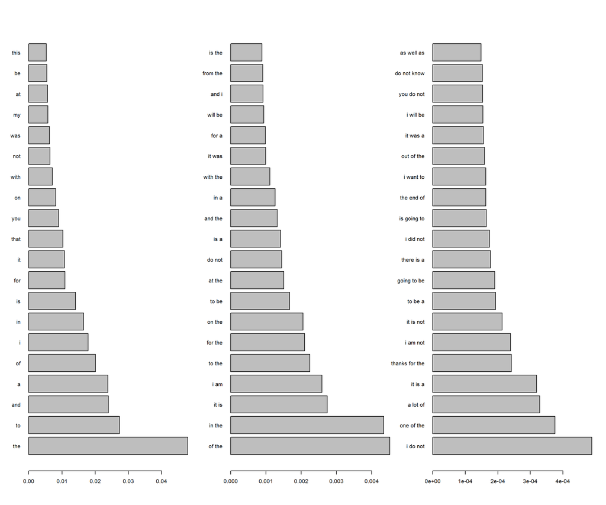

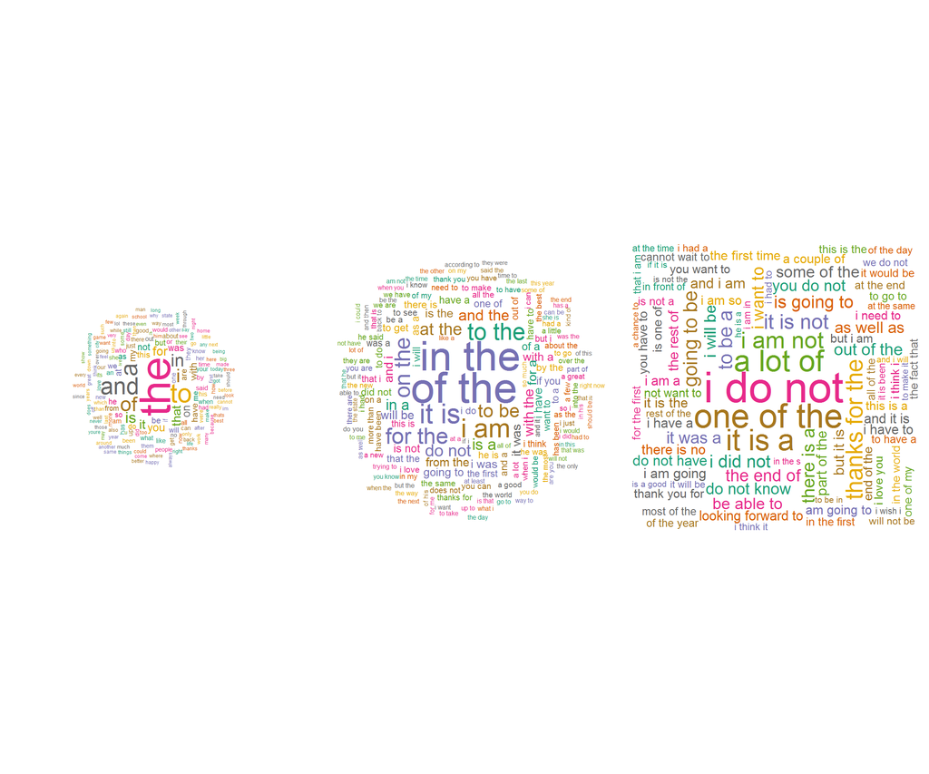

# Next Steps

- Reduce and improve predictive model, evaluating accuracy and efficiency.
- Create a shiny app to show off predictive algorithm.

# Appendix

```r
require("tm")
require("slam")
require("RWeka")
require("stringr")
require("wordcloud")

myTokenizer <- function (x) {
    ret <- x$content
    ret <- unlist(strsplit(ret, " "))
    ret <- gsub("[^a-zA-zèòàùèéùì]|\\[|\\]|\\\\|_|\\^|-|`", "", ret)
    return(ret[which(ret != "")])
}

unigramTokenizer <- function(x) {
    return(myTokenizer(x))
}

biGramTokenizer <- function(x) {
    return(NGramTokenizer(paste(myTokenizer(x), collapse = " "), Weka_control(min = 2, max = 2)))
}

triGramTokenizer <- function(x) {
    return(NGramTokenizer(paste(myTokenizer(x), collapse = " "), Weka_control(min = 3, max = 3)))
}

tdm_unigram <- TermDocumentMatrix(
    corpusT,
    control = list(
        tokenize = myTokenizer,
        weight = weightTf,
        tolower=TRUE,
        removeNumbers = FALSE,
        wordLengths = c(1, Inf),
        removePunctuation = FALSE,
        stopwords = FALSE
    ))

unigram_freq <- row_sums(tdm_unigram, na.rm = TRUE)
unigram_freq <- sort(unigram_freq, decreasing=TRUE)

tdm_bigram <- TermDocumentMatrix(
    corpusT,
    control = list(tokenize = biGramTokenizer,
                   weight = weightTf,
                   tolower=TRUE,
                   removeNumbers = FALSE,
                   wordLengths = c(1, Inf),
                   removePunctuation = FALSE,
                   stopwords = FALSE,
                   tolower = TRUE
    ))

bigram_freq <- row_sums(tdm_bigram, na.rm = TRUE)
bigram_freq <- sort(bigram_freq, decreasing=TRUE)

tdm_trigram <- TermDocumentMatrix(
    corpusT,
    control = list(tokenize = triGramTokenizer,
                   weight = weightTf,
                   tolower=TRUE,
                   removeNumbers = FALSE,
                   wordLengths = c(1, Inf),
                   removePunctuation = FALSE,
                   stopwords = FALSE,
                   tolower = TRUE
    ))

trigram_freq <- row_sums(tdm_trigram, na.rm = TRUE)
trigram_freq <- sort(trigram_freq, decreasing=TRUE)
```

# References

- http://citeseerx.ist.psu.edu/viewdoc/summary?doi=10.1.1.110.8518
- http://web.mit.edu/6.863/www/fall2012/readings/ngrampages.pdf
- https://class.coursera.org/nlp/lecture/129